# Validating fMRI

Joke Durnez

1/29/2018

# 1 Intro and setup

This notebook was originally developed for a short course for (graduate level) biostatisticians, as a short introduction to fMRI, as well as for cognitive neuroscientists with little to no knowledge of programming R. As such, for both groups, some parts will be too easy, some will be rather hard, but this is a statistics workshop, so *on average*, it should be fine :-)

## 1.1 Data

The data for this workshop are the [CNP data (UCLA Consortium for Neuropsychiatric Phenomics LA5c Study) - revision 1.0.5](https://openfmri.org/dataset/ds000030/), available on openfmri with a PPDL license. We will use the preprocessed data that is available on openfmri (preprocessed using fmriprep). On github, there are 2 python scripts available (in the preparation directory) to extract time series from the data, in order to avoid overloading wifi and losing time to get the data during the tutorial. Ideally, the instructor ran those scripts and provided the extracted time series for you.

# 2 Working with fMRI data using R

## 2.1 Recap: what is fMRI?

MRI is an imaging technique, with which we can take scans of muscles, bones, brains,… fMRI is when we repeatedly take MRI scans of the brain. This allows us to see the brain *in action* when it’s performing tasks or in rest etc.

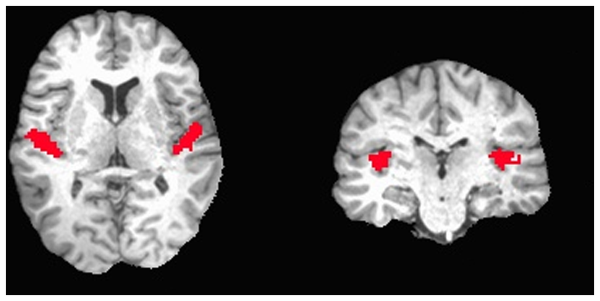

In reality, the analysis of the data is much more complex than ‘comparing images from two conditions’ and there exist thousands of ways to analyse the data. During this lesson, we will touch a few very basic methods, but a more thorough discussion is outside the scope. We will assume that all the data is preprocessed, which means that: - the data are corrected for motion - the data are corrected for distortions - the data from different subjects are aligned to a common template - …

## 2.2 Reading and visualising fMRI data with R/neuroconductor.

After opening RStudio, we want to set our working directory to the directory we created during set up, where we can find the data:

```r
setwd("~/Desktop/validating-fmri/")
```

Neuroconductor is an open-source platform for analysing neuroimaging (and other) data. It hosts multiple packages to analyse data using different software. We will mostly use its base library `neurobase`. To install, run:

```r
source("https://neuroconductor.org/neurocLite.R")
neuro_install("neurobase", release = "stable")
```

The data is located in the directory `data` in the working directory. Now we can load the data into R using the function `readnii`.

```r
library(neurobase)
data <- readnii("data/sub-10159/sub-10159_task-rest_bold_space-MNI152NLin2009cAsym_preproc.nii.gz")
```

```r
dim(data)
```

```
## [1]  65  77  49 152
```

This shows us that the first three dimensions are `65 x 77 x 49`. These correspond to the x-, y- and z-coordinates of the brain. The fourth dimension is time, which means there are 152 time points measured.

We can also run a function from `neurobase` that only works on this type of object:

```r
check_nifti(data)
```

```
## NIfTI-1 format
##   Type            : nifti
##   Data Type       : 16 (FLOAT32)
##   Bits per Pixel  : 32
##   Slice Code      : 0 (Unknown)
##   Intent Code     : 0 (None)
##   Qform Code      : 2 (Aligned_Anat)
##   Sform Code      : 1 (Scanner_Anat)
##   Dimension       : 65 x 77 x 49 x 152
##   Pixel Dimension : 3 x 3 x 4 x 2
##   Voxel Units     : Unknown
##   Time Units      : sec
```

Another interesting function is the visualisation of nifti’s. Note that we only visualise one timepoint, the first one. R will automatically show the first timepoint.

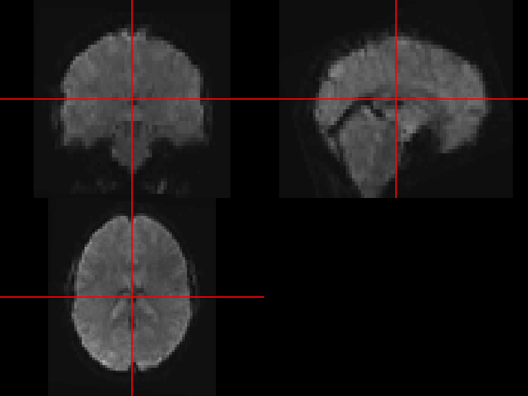

```r
orthographic(data)
```

If you’re not sure about how to use a certain function, you can call for help:

```r
?orthographic
```

You will see that there are many more arguments that can be passed to the function `orthographic`. For example the argument `xyz` allows us to specify where to draw the cross-hairs. Let’s try the following:

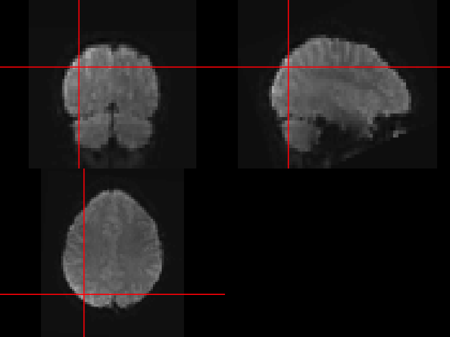

```r
orthographic(data,xyz=c(20,20,30))
```

To look at the `value` of one specific point in time and space, we can use indexes. Remember our cross-hair in the figure was at the first timepoint at coordinates (20,20,30).  
The following example shows the exact value of this point in the figure at the first timepoint.

```r
data[20,20,30,1]
```

```
## [1] 1148.524
```

```r
data[20,20,30,]
```

```
##   [1] 1148.524 1148.461 1142.563 1141.060 1127.099 1131.675 1135.632
##   [8] 1128.941 1160.061 1161.512 1137.481 1116.822 1109.309 1109.323
##  [15] 1093.169 1110.955 1109.561 1116.910 1134.975 1118.357 1132.719
##  [22] 1150.193 1165.766 1173.594 1176.839 1142.286 1145.902 1159.892
##  [29] 1152.587 1136.450 1127.974 1148.936 1152.663 1174.247 1168.272
##  [36] 1147.255 1159.906 1184.832 1145.608 1141.148 1132.086 1137.863
##  [43] 1133.563 1143.711 1141.173 1128.889 1124.897 1132.619 1144.724
##  [50] 1153.767 1133.262 1135.230 1137.793 1165.782 1160.442 1159.418
##  [57] 1165.768 1156.091 1169.558 1182.266 1167.106 1157.483 1163.735
##  [64] 1131.992 1121.514 1111.989 1121.143 1141.684 1122.967 1126.063
##  [71] 1121.025 1138.645 1132.201 1133.171 1132.688 1134.140 1127.046
##  [78] 1127.342 1134.374 1148.151 1147.634 1145.883 1143.286 1142.210
##  [85] 1138.209 1123.161 1148.567 1149.430 1155.253 1115.818 1116.521
##  [92] 1119.263 1136.349 1144.674 1151.027 1158.472 1145.075 1124.284
##  [99] 1120.904 1129.625 1131.517 1120.666 1126.623 1109.636 1093.798
## [106] 1126.940 1126.045 1120.136 1133.749 1101.970 1098.026 1116.716
## [113] 1142.895 1143.010 1138.357 1127.057 1102.292 1122.499 1136.995
## [120] 1126.363 1137.567 1122.647 1142.551 1131.645 1125.780 1120.023
## [127] 1122.369 1132.125 1104.158 1107.103 1088.539 1116.694 1149.974
## [134] 1146.161 1140.482 1114.848 1099.089 1121.268 1141.496 1141.877
## [141] 1129.998 1106.165 1107.426 1105.125 1089.509 1103.882 1114.204
## [148] 1113.552 1096.908 1104.983 1102.881 1121.604
```

If we plot this vector, we can see how the measured signal in this voxel changes over time.

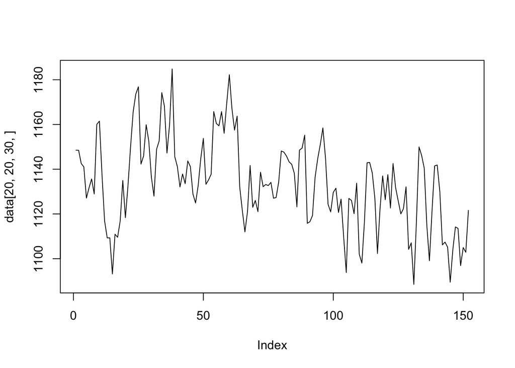

```r
plot(data[20,20,30,],type='l')
```

## 2.3 Optional excercices

Now that we know how to read, inspect and visualise fMRI data, it’s time for some exercises ! In the data-folder, there is for each subject 3 nifti-images:

- mask: sub-XXXXX_task-rest_bold_space-MNI152NLin2009cAsym_brainmask.nii.gz
- rest: sub-XXXXX_task-rest_bold_space-MNI152NLin2009cAsym_preproc.nii.gz
- anatomical: sub-XXXXX_T1w_preproc.nii.gz

We have looked at the functional rest data. Now look at the anatomical scan yourself.

- Read in the anatomical data.
- What are the dimensions of the anatomical data? Compare with the dimensions of the rest scan.
- Visualise the data.
- Set the color of the cross-hairs to `blue`
- Look at what the function `double_ortho` does, and use it to plot the rest scan (the first timepoint) and the anatomical scan.

# 3 Resting state fMRI

## 3.1 Recap: what is functional connectivity?

Before, we’ve worked with brain scans of subjects while they are performing specific tasks. However, another field of research within neuroimaging is about what the brain does during rest. It has been shown to be a valuable source to figure out how the brain is logically organised, and how the parts of the brain communicate with each other.

One interesting line of research is about creating atlases, where the brain is divided into different parts, for example using unsupervised learning (for example principle components analysis). Another research is about finding the *‘functional’* connections between those parts, for example by looking at the correlations between the average signal in those brain parcels.

### 3.1.1 Extracting time series data

```r
library(RColorBrewer)
library(scales)
library(lattice)
library(Rcmdr)
```

Let’s look at the anatomical data for our first subject.

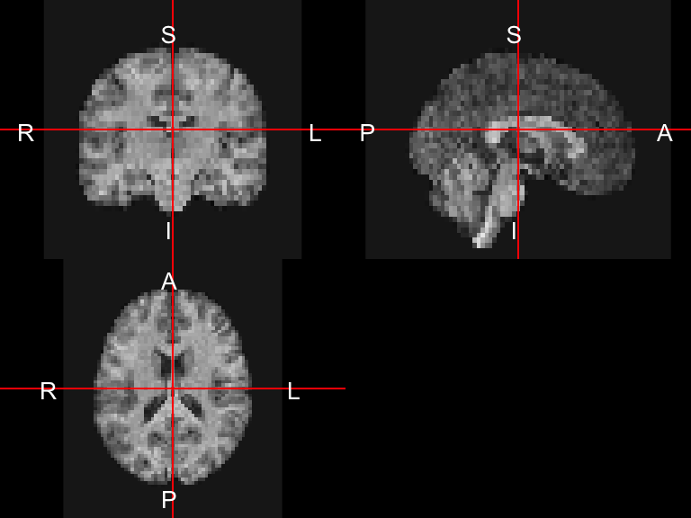

```r
sub10159_anat <- readnii("data/sub-10159/sub-10159_T1w_space-MNI152NLin2009cAsym_preproc_reduced.nii.gz")
ortho2(sub10159_anat)
```

And this is an atlas. Note that this is not the original atlas, but a low-resolution version to work with in this course. If you want the original atlas: https://team.inria.fr/parietal/18-2/spatial_patterns/spatial-patterns-in-resting-state/

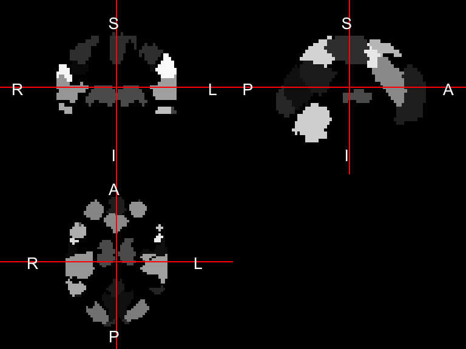

```r
atlas <- readnii("data/MSDL_rois/msdl_rois_reduced_reshaped.nii")
ortho2(atlas)
```

With a few extra plotting functions using colorbrewer and the `scales` library, we can create a cool overlay of the atlas on the anatomical scan:

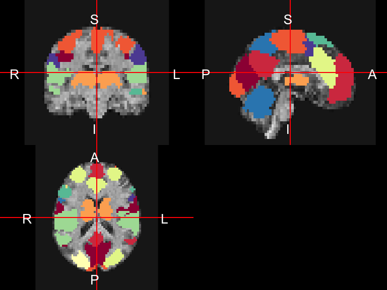

```r
cols <- brewer.pal(11,'Spectral')

ortho2(sub10159_anat,atlas,col.y=cols)
```

Now we want to extract a certain brain region, for example BROCA from the resting state data.

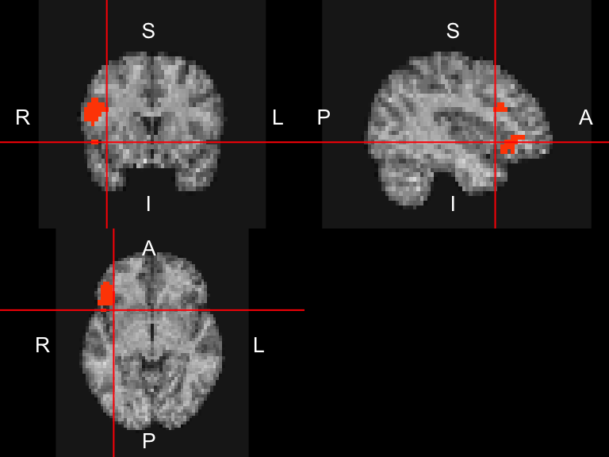

```r
broca <- ifelse(atlas==29,1,0)
ortho2(sub10159_anat,broca,xyz=c(20,50,19))
```

Now we want to extract the average signal in this area:

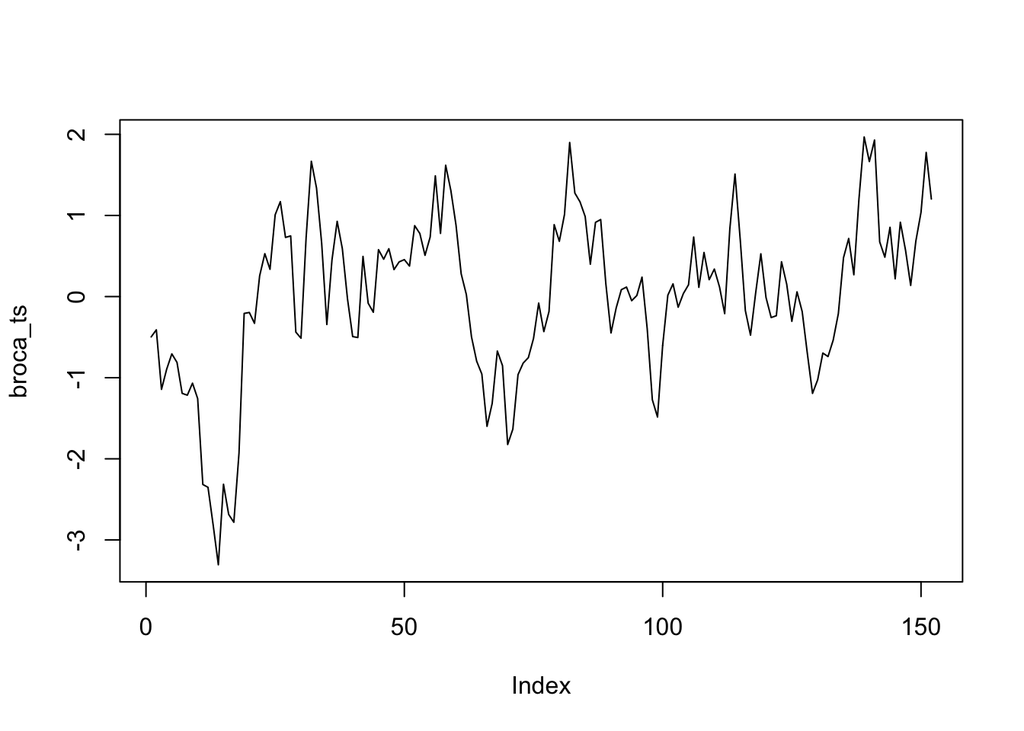

```r
broca_mask <- array(rep(broca,152),dim=dim(data))
broca_ts <- apply(data*broca_mask,4,sum)
broca_ts <- (broca_ts-mean(broca_ts))/sd(broca_ts)
plot(broca_ts,type='l')
```

Let’s write a function to do this:

```r
extract_signal <- function(data,atlas,mask_id){
  mask <- ifelse(atlas==mask_id,1,0)
  expand_mask <- array(rep(mask,dim(data)[4]),dim=dim(data))
  data_masked <- data*expand_mask
  ts <- apply(data_masked,4,sum)
  ts <- (ts - mean(ts))/sd(ts)
  ts
}
```

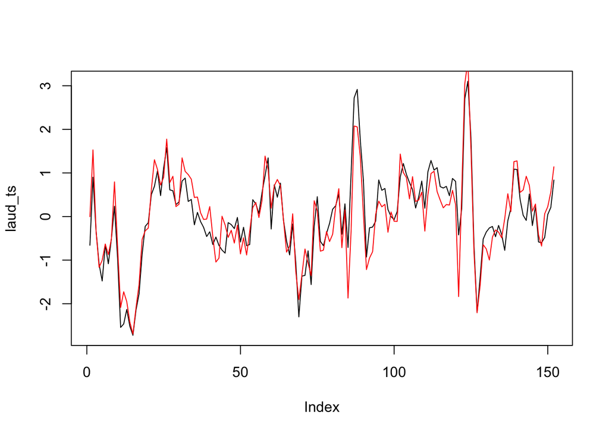

```r
laud_ts <- extract_signal(data,atlas,1)
plot(laud_ts,type="l")
raud_ts <- extract_signal(data,atlas,2)
lines(raud_ts,col=2)
```

### 3.1.2 Computing functional connectivity

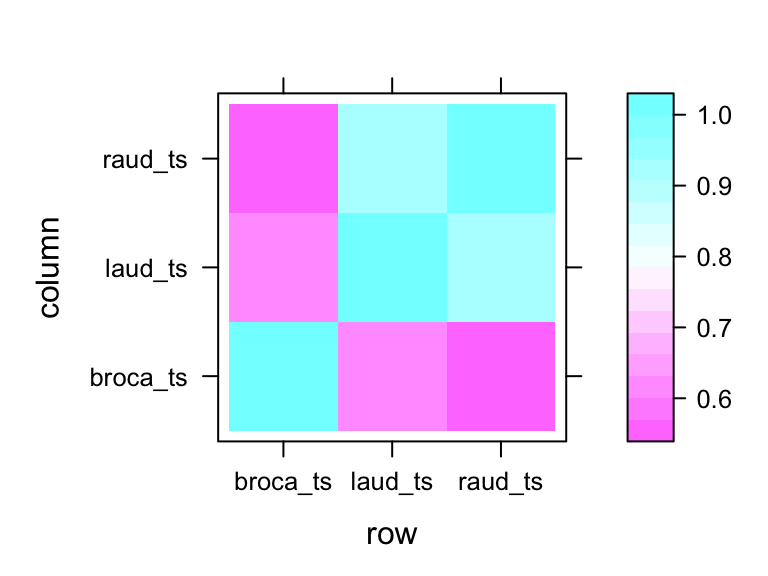

```r
together <- data.frame(broca_ts,laud_ts,raud_ts)
correlations = cor(together)
levelplot(correlations)
```

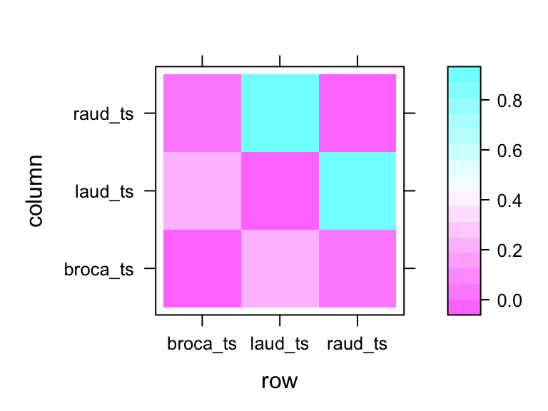

```r
estimate <- partial.cor(together,tests=TRUE)
levelplot(estimate$R)
```

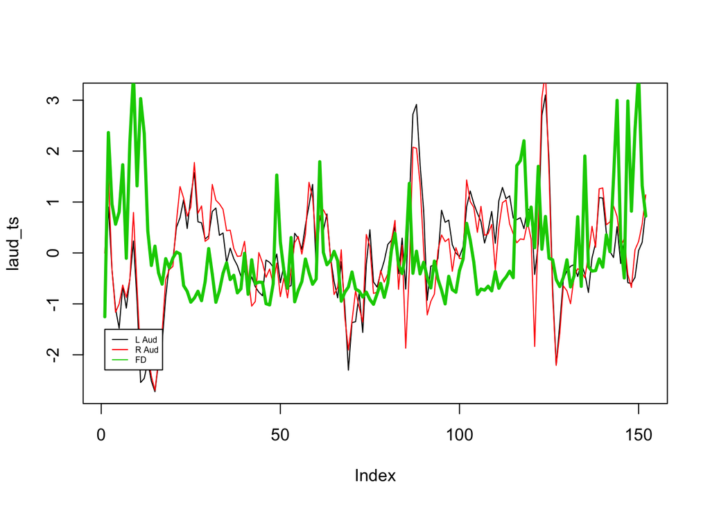

```r
confounders <- read.table("data/sub-10159/sub-10159_task-rest_bold_confounds.tsv",sep="\t",header=TRUE,na.strings='n/a',colClasses='numeric')
fd <- confounders$FramewiseDisplacement
# there is no value for the fd on the first timepoint --> set to 0
fd[1] <- 0
fd <- (fd-mean(fd))/sd(fd)
plot(laud_ts,type="l")
lines(raud_ts,col=2)
lines(fd,col=3,lwd=3)
legend(-1.5,c("L Aud","R Aud","FD"),col=1:3,lty=1,cex=0.5)
```

## 3.2 Optional exercises

- Can you extract the timeseries in subject 10365 for the different parts of the DMN. The atlas labels are: (4, Left DMN); (5, Median DMN); (6, Frontal DMN); (7, Right DMN)?
- Also try the following:
  - plot the time series together with the framewise displacement
  - what are the correlations
  - what happens if you add the motion to the time series when computing the partial correlations?
- Advanced:
  - Can you regress out the motion from the time series?
  - Can you regress out all motion parameters from the time series?
  - What happens with the correlations?
  - Can you extract (using a loop) the time series for all parts of the atlas?
  - Plot the correlation matrix and the partial correlation matrix.

# 4 Validating fMRI as in Eklund (2017)

## 4.1 The Eklund paper

Last year, Anders Eklund published a paper validating cluster inference. He found that the false positive rate is sometimes **much** higher than the nominal level. His really cool approach was to ‘pretend’ the resting state data is in fact coming from a task experiment with a random design matrix. Given that the participants (and the experimentors) were unaware of the task, the null hypothesis should be true.

## 4.2 Generate random designs using `neuRosim`

```r
library(neuRosim)
```

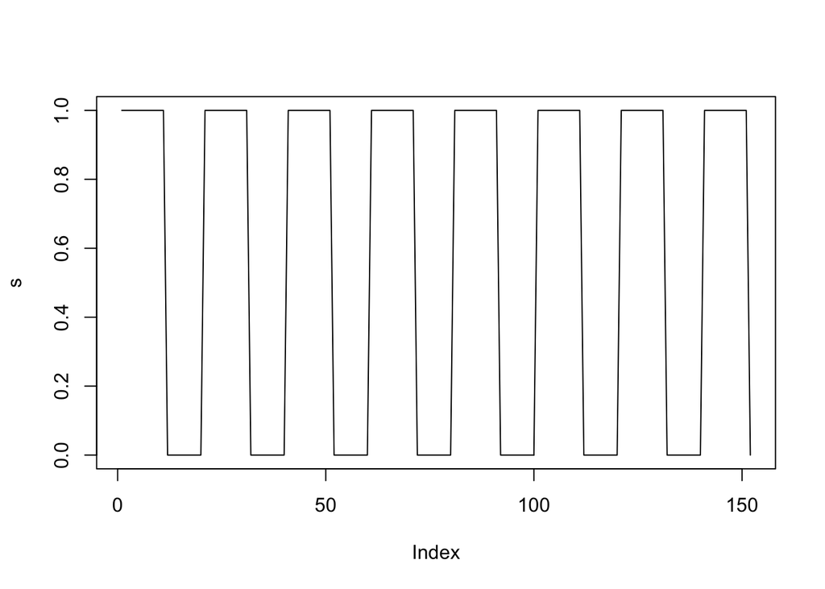

```r
totaltime <- 152*2
onsets <- seq(1,totaltime,40)
dur <- 20
s <- specifydesign(totaltime=totaltime,
                onsets=list(onsets),
                durations=dur,
                accuracy=1,
                effectsize=1,
                TR=2)
plot(s,type='l')
```

We could probably expect neurons to be firing very fast, but the signal that we measure is a **dependent** of the oxygen in the blood which comes only a few seconds later. The signal that we expect looks like this:

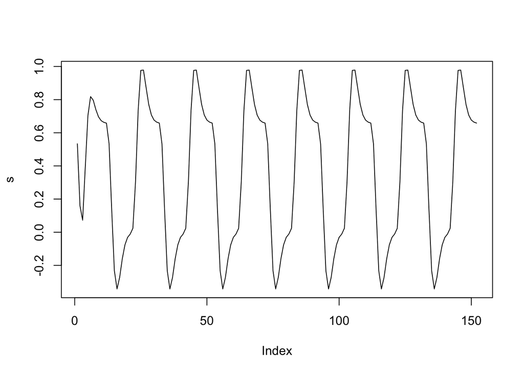

```r
s <- specifydesign(totaltime=totaltime,
                onsets=list(onsets),
                durations=dur,
                accuracy=1,
                effectsize=1,
                TR=2,
                conv='double-gamma')
plot(s,type='l')
```

If we would now estimate whether a voxel is *significantly* related to the task, we would regress the signal from a resting state dataset onto this design matrix. If we do that, we can assume the null hypothesis: any relation between the design and the signal is by chance.

Ideally, we would now do this for all voxels, but for computational reasons, we’ll focus on parcels (1000’s of voxels vs 39 parcels). Ideally, we would now extract the time series ourselves, but of or computational reasons, the time series are already extracted in the data folder (`CNP_ts/`). Let’s look at one subject.

```r
datdir <- 'data/CNP_ts/'
files <- list.files(datdir)
ts <- read.table(paste0(datdir,files[2]),sep=",")
head(ts,2)
```

```
##           V1        V2        V3         V4        V5        V6         V7
## 1 -0.1950061 0.2783514 -0.559840 -0.3996359 1.0245059 1.0665180  0.1788859
## 2 -0.5303118 0.1370437 -0.731119 -0.5694947 0.7857156 0.4777555 -0.1150351
##          V8         V9      V10      V11       V12      V13      V14
## 1 0.6270506  0.1775939 1.417099 1.261883 0.7566771 2.252137 1.569789
## 2 0.1530690 -0.3995555 1.136001 1.172791 0.3141784 1.583866 1.139964
##         V15      V16        V17        V18        V19       V20        V21
## 1 1.3837699 1.318610  0.3197243 -0.3064194 -0.4392510 -0.898600 -0.4151906
## 2 0.9155217 1.027048 -0.6107545 -0.6941234 -0.8259567 -1.006105 -0.4625272
##          V22          V23       V24       V25        V26        V27
## 1 -0.3008893 1.0183324243 1.1613632 1.1515451  0.3756378  0.1103843
## 2 -0.4666169 0.0007187072 0.8576137 0.5978735 -0.3542256 -0.5289335
##          V28       V29      V30       V31      V32        V33        V34
## 1  0.1391557 0.3727925 0.831866 -1.354775 1.777831 0.07237729 -0.3987264
## 2 -0.1650633 0.0348114 0.247771 -1.256893 1.514126 0.04430596 -0.8933236
##           V35       V36       V37        V38        V39
## 1 -0.03841347 -1.038179 1.2687749 -0.2517349 -0.6559813
## 2 -0.27476992 -1.729911 0.9014437 -0.7673380 -0.9268040
```

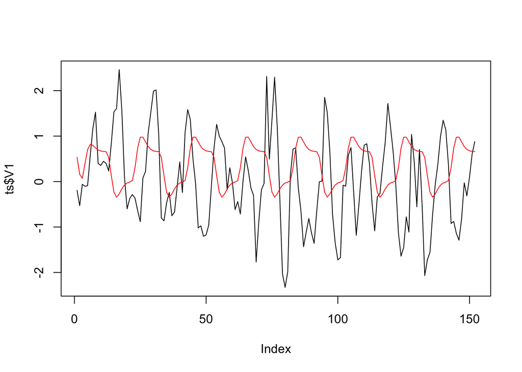

```r
plot(ts$V1,type="l")
lines(s,col=2)
```

Now let’s regress our data onto a random design.

```r
ts$design <- s
model <- lm("V1 ~ design",data=ts)
summary(model)
```

```
##
## Call:
## lm(formula = "V1 ~ design", data = ts)
##
## Residuals:
##      Min       1Q   Median       3Q      Max
## -2.48198 -0.73232 -0.02282  0.74389  2.37832
##
## Coefficients:
##             Estimate Std. Error t value Pr(>|t|)
## (Intercept)   0.1417     0.1049   1.351   0.1788
## design       -0.3898     0.1851  -2.106   0.0369 *
## ---
## Signif. codes:  0 '***' 0.001 '**' 0.01 '*' 0.05 '.' 0.1 ' ' 1
##
## Residual standard error: 0.9921 on 150 degrees of freedom
## Multiple R-squared:  0.02871,    Adjusted R-squared:  0.02224
## F-statistic: 4.434 on 1 and 150 DF,  p-value: 0.03689
```

```r
summary(model)$coefficients
```

```
##               Estimate Std. Error   t value   Pr(>|t|)
## (Intercept)  0.1416964  0.1048957  1.350832 0.17878356
## design      -0.3898186  0.1851187 -2.105777 0.03688945
```

```r
pval <- summary(model)$coefficients[2,4]
tval <- summary(model)$coefficients[2,3]
print(paste("pvalue: ",pval," - tvalue:",tval))
```

```
## [1] "pvalue:  0.0368894469806956  - tvalue: -2.10577655168616"
```

## 4.3 Using this idea to validate fMRI analysis

Now we can loop this.

```r
pvals <- c()
tvals <- c()
i = 1
for (file in files){
  ts <- read.table(paste0(datdir,file),sep=",")
  ts$design <- s
  model <- lm("V1 ~ design",data=ts)
  pvals[i] <- summary(model)$coef[2,4]
  tvals[i] <- summary(model)$coef[2,3]
  i = i+1
}
sum(pvals<0.05)/length(pvals)
```

```
## [1] 0.2192308
```

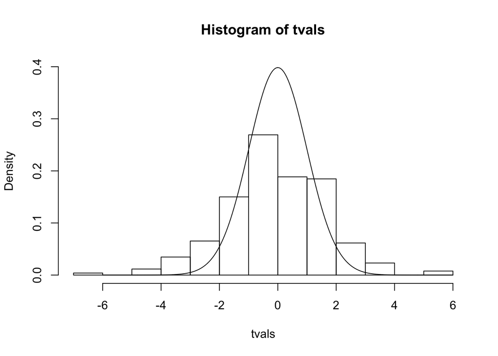

```r
hist(tvals,freq=FALSE,ylim=c(0,0.4))
x <- seq(-6,6,length=1000)
y <- dt(x,151)
lines(x,y)
```

## 4.4 Taking into account temporal auto-correlations

### 4.4.1 How to take into account the temporal auto-correlation

```r
create_white <- function(ntp,rho){
  V2 <- diag(ntp)
  V2 <- rho^abs(row(V2)-col(V2))
  W <- solve(V2^(1/2))
}
```

```r
W <- create_white(152,0.3)
ts$design_wh <- W%*% matrix(ts$design)
ts$V1_wh <- W %*% matrix(ts$V1)

model <- lm("V1_wh ~ design_wh",data=ts)
summary(model)
```

```
##
## Call:
## lm(formula = "V1_wh ~ design_wh", data = ts)
##
## Residuals:
##      Min       1Q   Median       3Q      Max
## -15.6995  -0.4197  -0.0333   0.4512  12.5813
##
## Coefficients:
##             Estimate Std. Error t value Pr(>|t|)
## (Intercept) -0.06567    0.19823  -0.331    0.741
## design_wh    0.56789    0.82175   0.691    0.491
##
## Residual standard error: 2.18 on 150 degrees of freedom
## Multiple R-squared:  0.003174,   Adjusted R-squared:  -0.003472
## F-statistic: 0.4776 on 1 and 150 DF,  p-value: 0.4906
```

```r
pval <- summary(model)$coef[2,4]
tval <- summary(model)$coef[2,3]
print(paste("pvalue: ",pval," - tvalue:",tval))
```

```
## [1] "pvalue:  0.490582639996256  - tvalue: 0.691081185968301"
```

### 4.4.2 Include this approach into our simulations

```r
pvals <- c()
tvals <- c()
i = 1
for (file in files){
  ts <- read.table(paste0(datdir,file),sep=",")
  ts$design <- s
  ts$design_wh <- W%*% matrix(ts$design)
  ts$V1_wh <- W %*% matrix(ts$V1)
  model <- lm("V1_wh ~ design_wh",data=ts)
  pvals[i] <- summary(model)$coef[2,4]
  tvals[i] <- summary(model)$coef[2,3]
  i = i+1
}
sum(pvals<0.05)/length(pvals)
```

```
## [1] 0.02692308
```

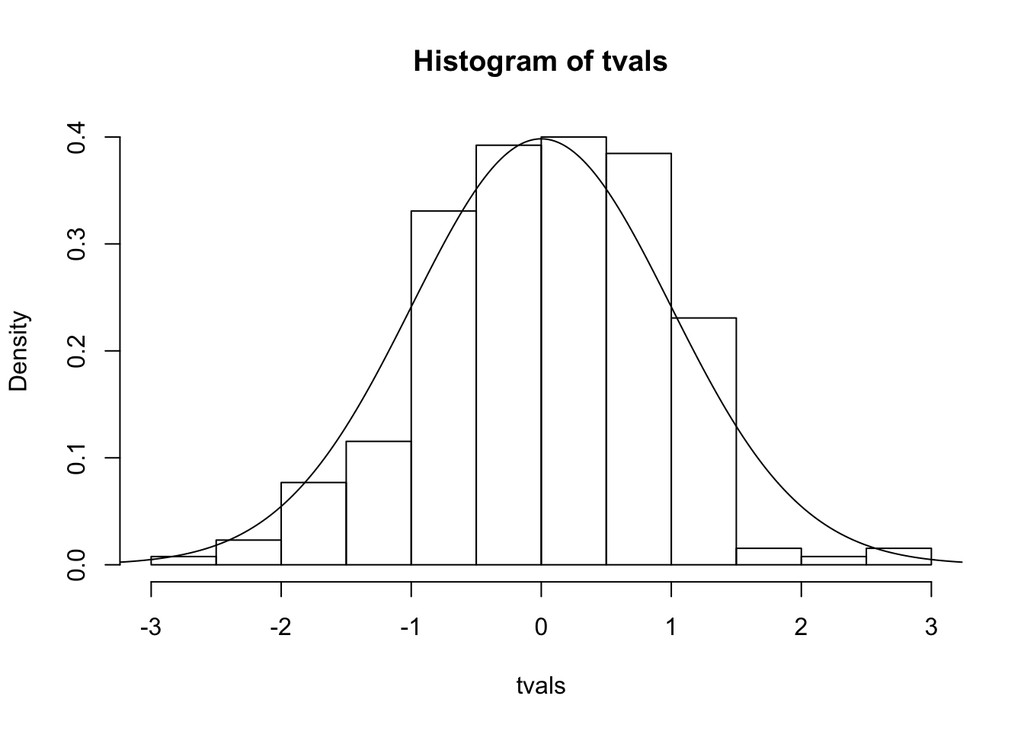

```r
hist(tvals,freq=FALSE,ylim=c(0,0.4))
x <- seq(-6,6,length=1000)
y <- dt(x,151)
lines(x,y)
```

## 4.5 Optional exercises

- What happens when you choose a more random design (onsets not evenly spaced)?
- What happens when you use a different autocorrelation value or function?
- Do you observe the same pattern in another?
- Can you make a loop (around the loop) that saves the false positive rate for all parcels.
- Advanced: in reality, we would want to estimate the autocorrelation from the data. How would you approach this?